# R Notebook

Question 1

Tidy up the data ready for regression:

```r
library(tidyverse)
library(modelr)

# visualisation packages
library(GGally)
library(ggfortify)

kc_house <- read_csv("data/kc_house_data.csv")
# remove columns suggested as not useful
kc_house_tidy <- kc_house %>%
  select(-c(id, date, sqft_living15, sqft_lot15, zipcode, long, lat)) %>%
  mutate(renovated = as.logical(yr_renovated),
         renovated = as.numeric(renovated),
         view = as_factor(view),
         condition = as_factor(condition),
         grade = as_factor(grade))

kc_house_tidy %>%
  distinct(grade)
```

| grade |
| --- |
| 7 |
| 6 |
| 8 |
| 11 |
| 9 |
| 5 |
| 10 |
| 12 |
| 4 |
| 3 |

[output cut: 2 more lines]

Question 2 Check for aliased variables using the alias() function (this takes in a formula object and a data set). [Hint - formula price ~ . says ‘price varying with all predictors’, this is a suitable input to alias()]. Remove variables that lead to an alias. Check the ‘Elements of multiple regression’ lesson for a dropdown containing further information on finding aliased variables in a dataset.

```r
alias(price ~ ., kc_house_tidy)
```

```
Model :
price ~ bedrooms + bathrooms + sqft_living + sqft_lot + floors +
    waterfront + view + condition + grade + sqft_above + yr_built +
    yr_renovated + renovated
```

Question 3 Systematically build a regression model containing up to four main effects (remember, a main effect is just a single predictor with coefficient), testing the regression diagnostics as you go * splitting datasets into numeric and non-numeric columns might help ggpairs() run in manageable time, although you will need to add either a price or resid column to the non-numeric dataframe in order to see its correlations with the non-numeric predictors.

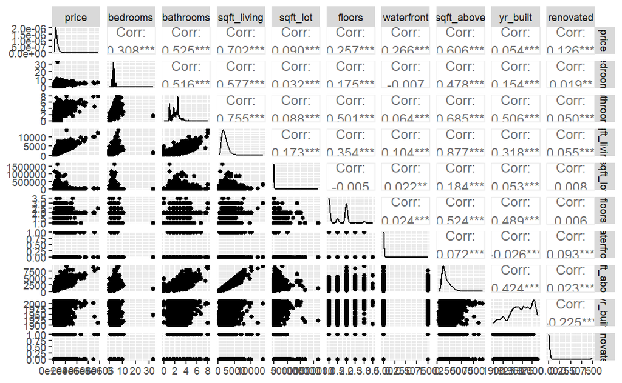

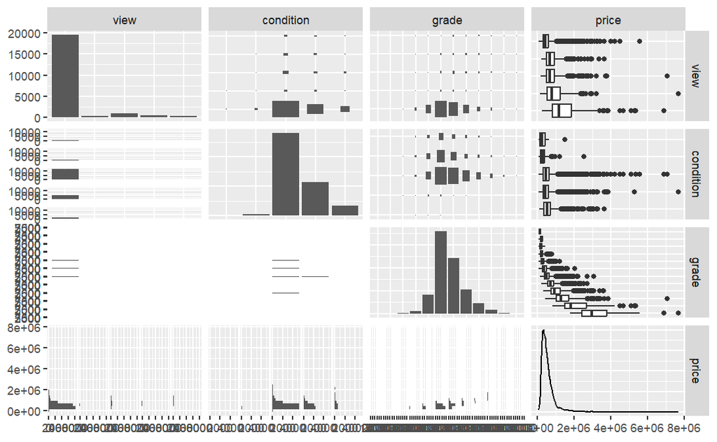

```r
ggpairs(houses_tidy_numeric, progress = FALSE)
# saves teh plot for future reference, can also provide dimensions to make it bigger
ggsave("ggpairs_numeric.png", width = 15, height = 15)
ggpairs(houses_tidy_nonnumeric, progress = FALSE)


ggsave("ggpairs_nonnumeric.png", width = 15, height = 15)
```

Error: attempt to use zero-length variable name

[output not shown]

```
Call:
lm(formula = price ~ sqft_living, data = kc_house_tidy)

Residuals:
     Min       1Q   Median       3Q      Max
-1476062  -147486   -24043   106182  4362067

Coefficients:
              Estimate Std. Error t value Pr(>|t|)
(Intercept) -43580.743   4402.690  -9.899   <2e-16 ***
sqft_living    280.624      1.936 144.920   <2e-16 ***
---
Signif. codes:  0 ‘***’ 0.001 ‘**’ 0.01 ‘*’ 0.05 ‘.’ 0.1 ‘ ’ 1

Residual standard error: 261500 on 21611 degrees of freedom
Multiple R-squared:  0.4929,    Adjusted R-squared:  0.4928
F-statistic: 2.1e+04 on 1 and 21611 DF,  p-value: < 2.2e-16
```

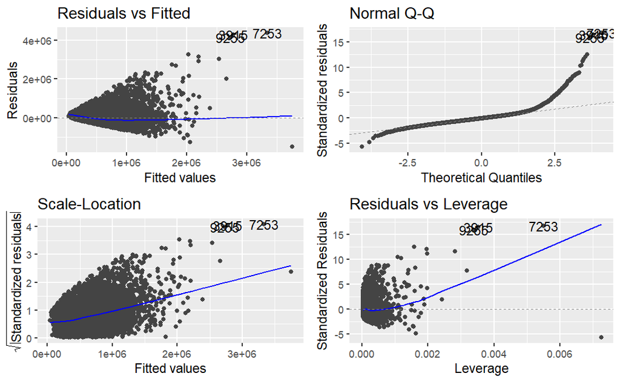

```r
autoplot(mod1)
```

```r
# example fo checking with anova

mod2 <- lm(price~sqft_living + grade, kc_house_tidy)
anova(mod1, mod2)
```

```
Analysis of Variance Table

Model 1: price ~ sqft_living
Model 2: price ~ sqft_living + grade
  Res.Df        RSS Df  Sum of Sq      F    Pr(>F)
1  21611 1.4773e+15
2  21600 1.2186e+15 11 2.5871e+14 416.89 < 2.2e-16 ***
---
Signif. codes:  0 ‘***’ 0.001 ‘**’ 0.01 ‘*’ 0.05 ‘.’ 0.1 ‘ ’ 1
```

```r
# example with grouping

houses_tidy <- kc_house_tidy %>%
  mutate(grade_grouped = as.factor(if_else(as.numeric(grade) < 8, 7,as.numeric(grade) )))
```

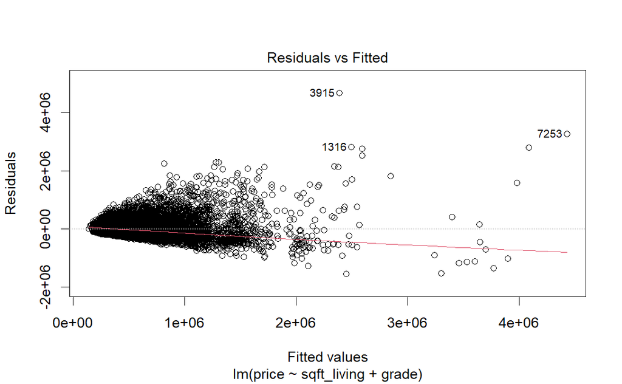

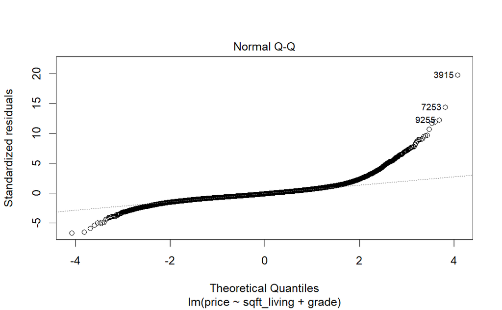

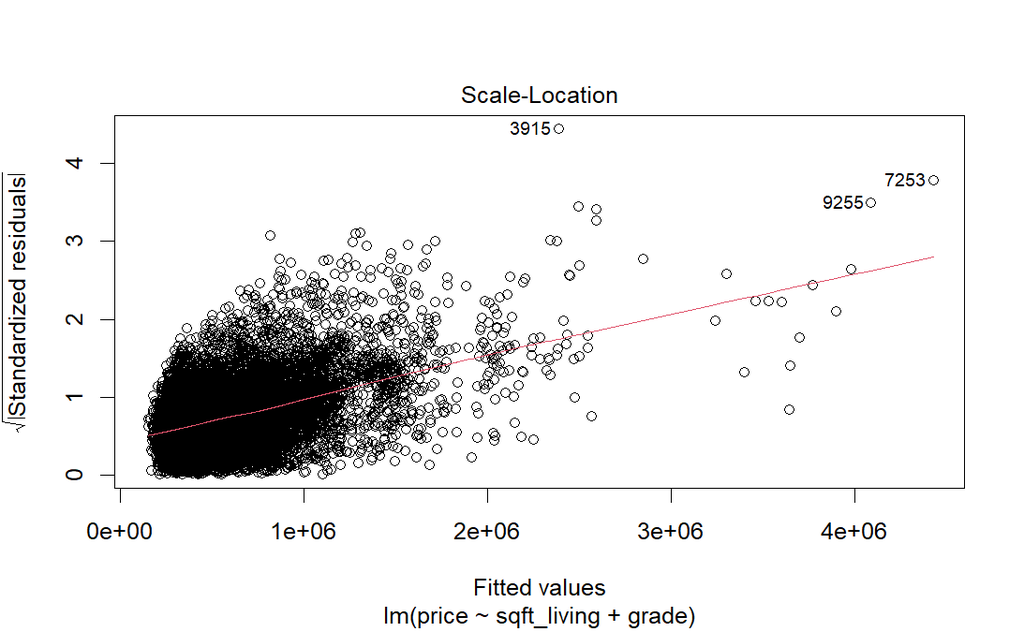

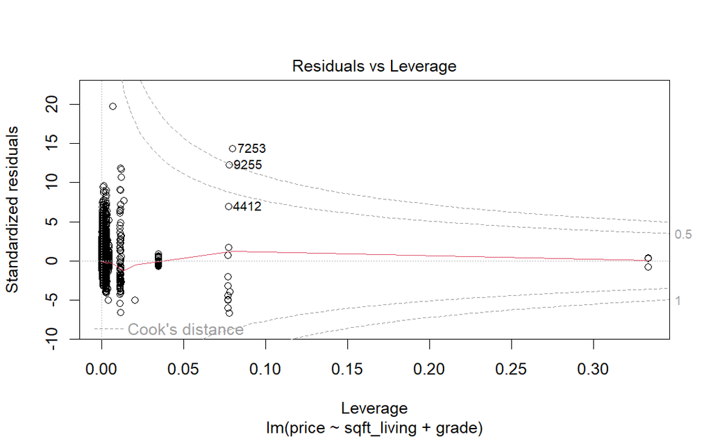

```r
plot(mod2)
```

```r
summary(mod2)
```

[output not shown]

```r
mod3 <- lm(price~ view, kc_house_tidy)
summary(mod3)
```

```
Call:
lm(formula = price ~ view, data = kc_house_tidy)

Residuals:
     Min       1Q   Median       3Q      Max
-1211711  -196564   -67564   108436  6728035

Coefficients:
            Estimate Std. Error t value Pr(>|t|)
(Intercept)   496564       2399  207.02   <2e-16 ***
view1         315717      18533   17.04   <2e-16 ***
view2         295837      11054   26.76   <2e-16 ***
view3         475401      15020   31.65   <2e-16 ***
view4         967147      18901   51.17   <2e-16 ***
---
Signif. codes:  0 ‘***’ 0.001 ‘**’ 0.01 ‘*’ 0.05 ‘.’ 0.1 ‘ ’ 1

Residual standard error: 334900 on 21608 degrees of freedom
Multiple R-squared:  0.1682,    Adjusted R-squared:  0.1681
F-statistic:  1093 on 4 and 21608 DF,  p-value: < 2.2e-16
```

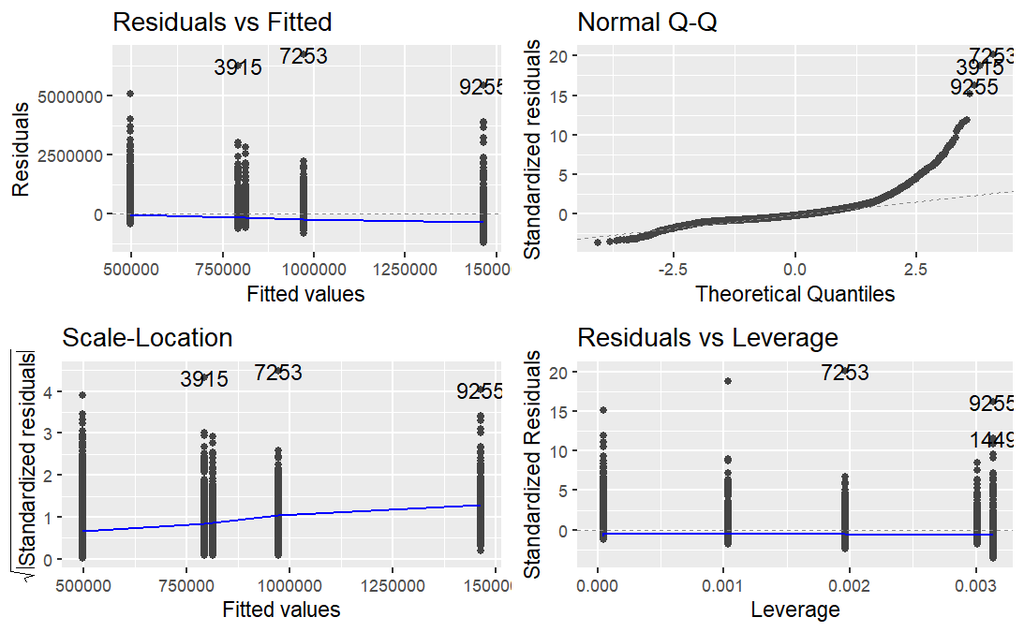

```r
autoplot(mod3)
```

```r
mod4 <- lm(price~ grade, kc_house_tidy)
summary(mod4)
```

```
Call:
lm(formula = price ~ grade, data = kc_house_tidy)

Residuals:
     Min       1Q   Median       3Q      Max
-1929615  -135853   -35090    89080  5565658

Coefficients:
            Estimate Std. Error t value Pr(>|t|)
(Intercept)   142000     254499   0.558 0.576878
grade3         63667     293870   0.217 0.828484
grade4         72381     258849   0.280 0.779767
grade5        106524     255024   0.418 0.676169
grade6        159920     254561   0.628 0.529868
grade7        260590     254513   1.024 0.305904
grade8        400853     254520   1.575 0.115285
grade9        631513     254547   2.481 0.013112 *
grade10       929771     254611   3.652 0.000261 ***
grade11      1354842     254817   5.317 1.07e-07 ***
grade12      2049222     255909   8.008 1.23e-15 ***
grade13      3567615     264106  13.508  < 2e-16 ***
---
Signif. codes:  0 ‘***’ 0.001 ‘**’ 0.01 ‘*’ 0.05 ‘.’ 0.1 ‘ ’ 1

Residual standard error: 254500 on 21601 degrees of freedom
Multiple R-squared:  0.5197,    Adjusted R-squared:  0.5195
F-statistic:  2125 on 11 and 21601 DF,  p-value: < 2.2e-16
```

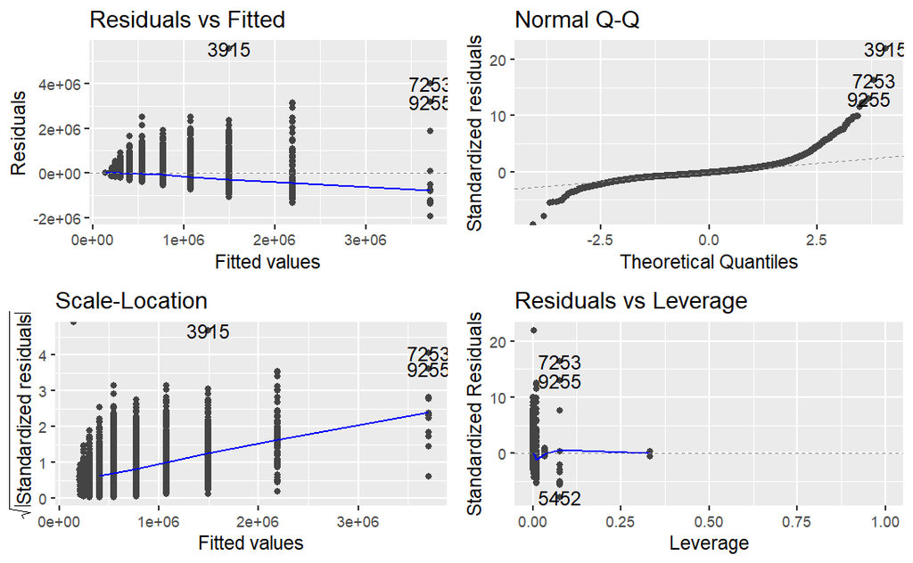

```r
autoplot(mod4)
```

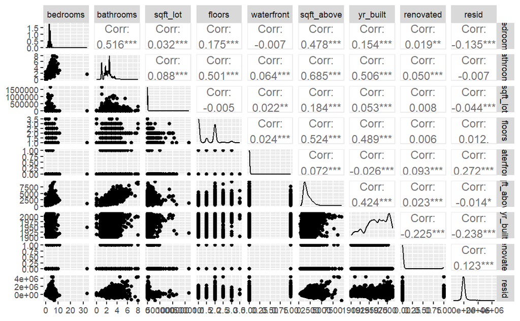

```r
# create a new data set called houses_remaining_resid
houses_remaining_resid <- houses_tidy_numeric %>%
  add_residuals(mod1) %>%
  select(-c("sqft_living", "price"))

houses_remaining_resid %>%
  ggpairs()
```

```r
anova(mod1, mod6a)
```

```
Analysis of Variance Table

Model 1: price ~ sqft_living
Model 2: price ~ sqft_living + view
  Res.Df        RSS Df  Sum of Sq      F    Pr(>F)
1  21611 1.4773e+15
2  21607 1.3278e+15  4 1.4944e+14 607.92 < 2.2e-16 ***
---
Signif. codes:  0 ‘***’ 0.001 ‘**’ 0.01 ‘*’ 0.05 ‘.’ 0.1 ‘ ’ 1
```

```r
mod6b <- lm(price ~ sqft_living + bathrooms, kc_house_tidy)
summary(mod6b)
```

```
Call:
lm(formula = price ~ sqft_living + bathrooms, data = kc_house_tidy)

Residuals:
     Min       1Q   Median       3Q      Max
-1483123  -147387   -24190   105951  4359876

Coefficients:
              Estimate Std. Error t value Pr(>|t|)
(Intercept) -39456.614   5223.129  -7.554 4.38e-14 ***
sqft_living    283.892      2.951  96.194  < 2e-16 ***
bathrooms    -5164.600   3519.452  -1.467    0.142
---
Signif. codes:  0 ‘***’ 0.001 ‘**’ 0.01 ‘*’ 0.05 ‘.’ 0.1 ‘ ’ 1

Residual standard error: 261400 on 21610 degrees of freedom
Multiple R-squared:  0.4929,    Adjusted R-squared:  0.4929
F-statistic: 1.05e+04 on 2 and 21610 DF,  p-value: < 2.2e-16
```

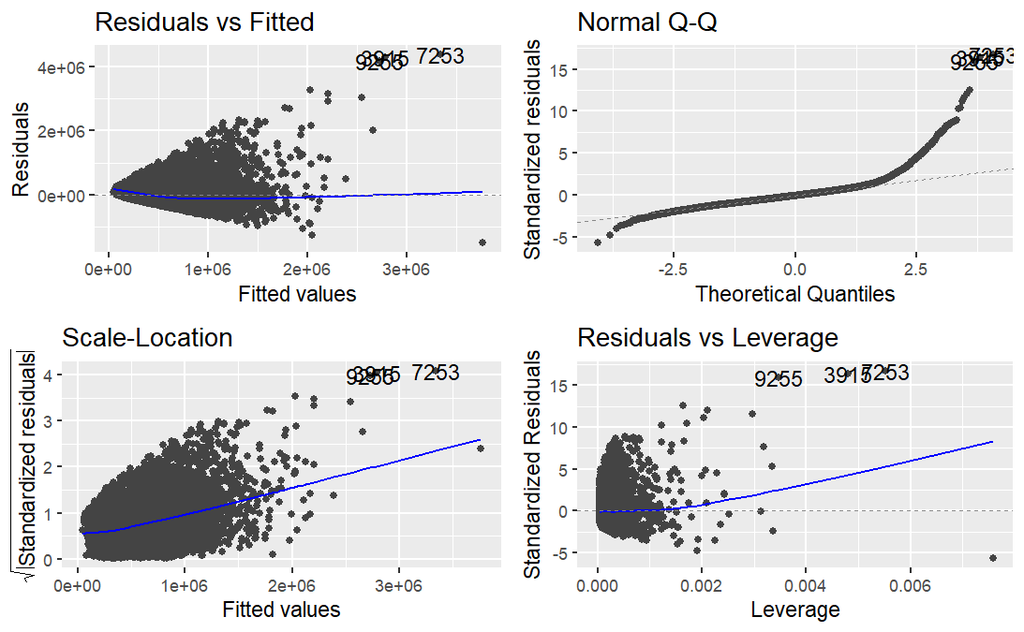

```r
autoplot((mod6b))
```

```r
anova(mod6b, mod1)
```

```
Analysis of Variance Table

Model 1: price ~ sqft_living + bathrooms
Model 2: price ~ sqft_living
  Res.Df        RSS Df   Sum of Sq      F Pr(>F)
1  21610 1.4771e+15
2  21611 1.4773e+15 -1 -1.4719e+11 2.1534 0.1423
```

[output not shown]

[output cut: 990 more lines]

So we have a model with the first predictor being sqft_living and second view

```r
anova(mod6a, mod7a)
```

```
Analysis of Variance Table

Model 1: price ~ sqft_living + view
Model 2: price ~ sqft_living + view + bathrooms
  Res.Df        RSS Df  Sum of Sq      F Pr(>F)
1  21607 1.3278e+15
2  21606 1.3278e+15  1 2.2905e+10 0.3727 0.5415
```

```r
mod7b <- mod7a <- lm(price ~ sqft_living + view + bathrooms, kc_house_tidy)
summary(mod7b)
```

```
Call:
lm(formula = price ~ sqft_living + view + bathrooms, data = kc_house_tidy)

Residuals:
     Min       1Q   Median       3Q      Max
-1787166  -138696   -19098   103831  4418793

Coefficients:
              Estimate Std. Error t value Pr(>|t|)
(Intercept) -16059.321   4979.121  -3.225  0.00126 **
sqft_living    254.486      2.871  88.627  < 2e-16 ***
view1       169784.086  13767.425  12.332  < 2e-16 ***
view2       127787.115   8282.805  15.428  < 2e-16 ***
view3       214394.590  11292.116  18.986  < 2e-16 ***
view4       621169.523  14239.401  43.623  < 2e-16 ***
bathrooms     2039.583   3340.824   0.611  0.54154
---
Signif. codes:  0 ‘***’ 0.001 ‘**’ 0.01 ‘*’ 0.05 ‘.’ 0.1 ‘ ’ 1

Residual standard error: 247900 on 21606 degrees of freedom
Multiple R-squared:  0.5442,    Adjusted R-squared:  0.544
F-statistic:  4299 on 6 and 21606 DF,  p-value: < 2.2e-16
```

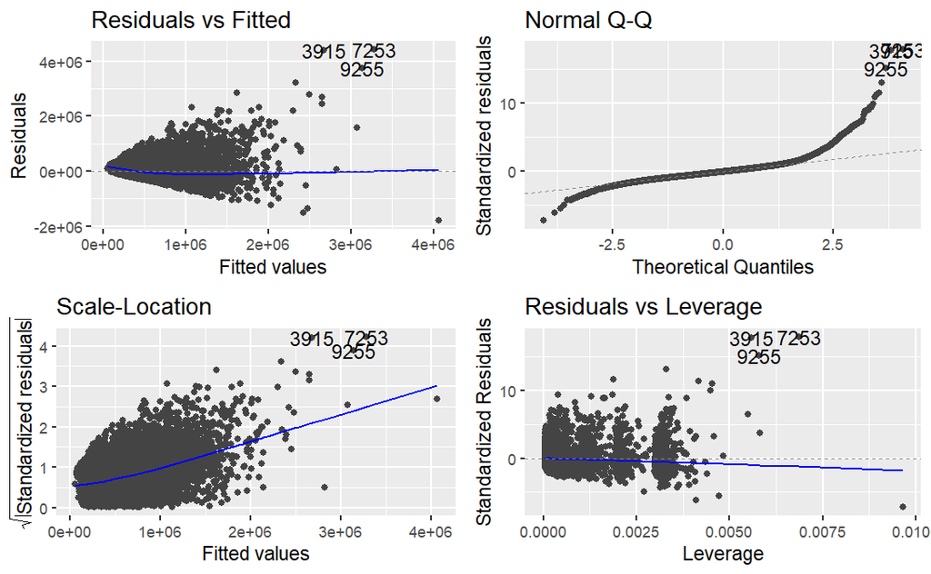

```r
autoplot(mod7b)
```

```r
anova(mod6a, mod7b)
```

```
Analysis of Variance Table

Model 1: price ~ sqft_living + view
Model 2: price ~ sqft_living + view + bathrooms
  Res.Df        RSS Df  Sum of Sq      F Pr(>F)
1  21607 1.3278e+15
2  21606 1.3278e+15  1 2.2905e+10 0.3727 0.5415
```

grade (especially 10-12) seem to have a greater significance than the number of bathrooms